# Module 6 — Species Interactions

Snapshot Brasil camera-trap analysis pipeline

# 1 What this module does

Modules 3–5 asked *where each species lives*. This module asks a harder question: **does one species’ abundance depend on another’s?** That is the difference between a map of co-occurrence and a claim about interaction — competition, predation, facilitation.

The module makes four moves:

1. **Why occupancy (co-occurrence) models are the wrong tool for inferring interactions**, and what the alternative is.
2. **Fit an abundance-mediated interaction model** for a focused set of driver-responder pairs, at **two spatial resolutions** — the ~1,100 individual camera stations, and the coarser 60-array partition used in Module 5 — since the papers this pipeline follows both fit this class of model on units closer to a home-range scale, and the two resolutions do not always agree.
3. **Compare the two resolutions directly** and consider why a conclusion can change depending on the spatial unit the interaction is estimated at.
4. **Build two community-level interaction networks** — one from the abundance model, one from GJAM’s residual co-occurrence — and read them together.

# 2 Why not occupancy models for interactions?

The most common way ecologists have tried to infer species interactions from camera-trap data is a **multi-species occupancy model**: fit occupancy for two species jointly and look at whether one species’ presence changes the other’s estimated occupancy probability, after habitat is accounted for. It is tempting because it uses exactly the same data already in hand — no separate model, no extra fieldwork.

It is also, on the current evidence, an unreliable way to detect interactions.

**Sample size.** Twining & Kellner (2026, *Methods in Ecology and Evolution* 17:456-479, doi: 10.1111/2041-210x.70210) ran a simulation study asking when hierarchical co-occurrence models can reliably recover a real two-species interaction. Their headline finding: datasets need **more than 500 sites** for two-species interactions to avoid a **type M (magnitude) error** — a confidently wrong *size* of effect — and they report that many previously published studies did not meet this minimum.

**Bias, not just noise.** The same paper identifies a more fundamental problem: even with enough sites, model misspecification — a shared habitat covariate or a third interacting species left out of the model — can produce a **type S (sign) error**: a confidently wrong *direction*, concluding avoidance when the truth is attraction, or vice versa. Both failure modes share a common mechanism, **omitted-variable bias**, the same problem that haunts ordinary linear regression; it does not go away with more data, only with the *right* covariates, which are rarely all known in advance. A related simulation study, Cowans, Bigata & Sutherland (2025, *Ecology* 106:e70175), independently confirms the sensitivity of co-occurrence inference to sample size and detection probability: bias in the interaction parameter is high below 100–1,000 sites depending on detection probability and interaction strength, and even at nearly 3,000 sites a *weak* co-occurrence signal is never consistently detected.

**What this means for this module**

Testing all 44×43 possible species pairs with an occupancy-style co-occurrence model would be both a multiple-testing fishing expedition and, per the above, statistically unreliable even before the multiple-testing problem is considered. This module instead uses an **abundance-mediated** approach — an N-mixture model where one species’ *estimated abundance* enters as a covariate in another’s abundance model — on a small, hypothesis-driven set of pairs, following the modeling approach of Amir, Sovie & Luskin (2022, *Ecology and Evolution*, doi: 10.1002/ece3.9627) and the sample-size-aware precedent of Twining (2025).

## 2.1 The power difference, on our own data

Before trusting the abundance-mediated results below, it is worth showing — not just asserting — that abundance carries more signal than presence/absence on this dataset. Three pairs were refit *both* ways, occupancy-mediated (co-occurrence) and abundance-mediated, on the same camera-level sites:

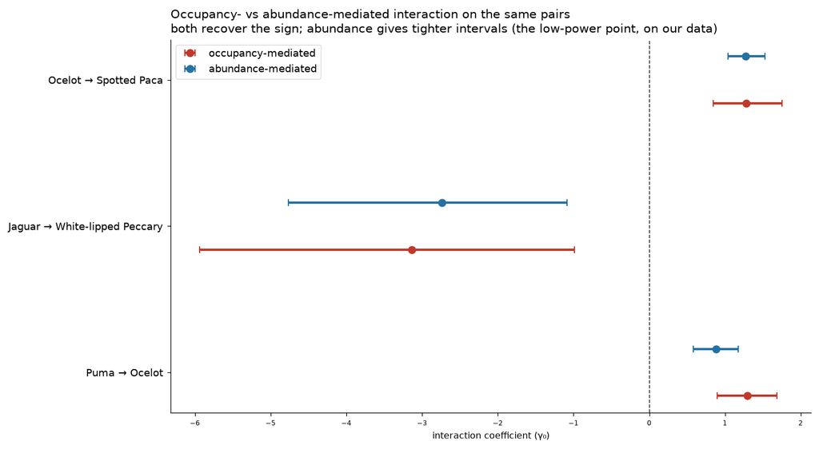

Figure 1: Occupancy- vs abundance-mediated interaction coefficient on three pairs, camera-level. Both recover the same sign; the abundance version yields consistently tighter credible intervals — the low-power cost of the occupancy channel, on our own data.

Both parameterisations recover the **same sign** on all three pairs — reassuring — but the abundance intervals are narrower every time. The lesson is not “occupancy is always wrong” but “occupancy spends power you cannot afford,” which is why every interaction below is estimated on abundance.

# 3 Which pairs, and why

Following the papers’ advice above, a focused set of pairs is tested rather than every possible combination:

- **12 a-priori pairs** — hypotheses from natural history: apex predators and their large prey (Jaguar → peccaries, tapir), mesopredator suppression (Jaguar/Puma → Ocelot → smaller cats), and competing frugivore/rodent guilds (agoutis, acouchi, paca).
- **8 GJAM-flagged pairs** — the strongest residual co-occurrences from the Module 4 joint model (association *not* explained by shared habitat), promoted to a formal abundance test.
- **10 dog-driven pairs** (array level only) — domestic dog abundance as the driver, against a set of native species plausibly affected by dogs as a disturbance/competitor, since dogs are a human-associated species outside the a-priori and GJAM-flagged sets above.

All 20 a-priori/GJAM pairs were fit at **both** spatial resolutions; the 10 dog-driven pairs were added only once the array-level rebuild was in place and so exist at array level only.

# 4 Camera-level results: the abundance-mediated network

The camera-level model fits each of the 12 a-priori and 8 GJAM-flagged pairs (plus the reverse direction for every cross-trophic pair) at the ~1,100 individual camera stations, using the full 11-covariate CAMERA_SET. This is the finer-grained, larger-sample-size fit: 20 driver→ responder pairs, 27 total model fits once reverse directions are included.

Camera-level fitting summary. Most pairs required the overdispersion random effect.

| Quantity | Value |
| --- | --- |
| Pairs fit (a-priori) | 12 |
| Pairs fit (GJAM-flagged) | 8 |
| Total fits (incl. reverse direction) | 27 |
| Refit with ODRE | 16 |
| Passing posterior-predictive check | 26 |

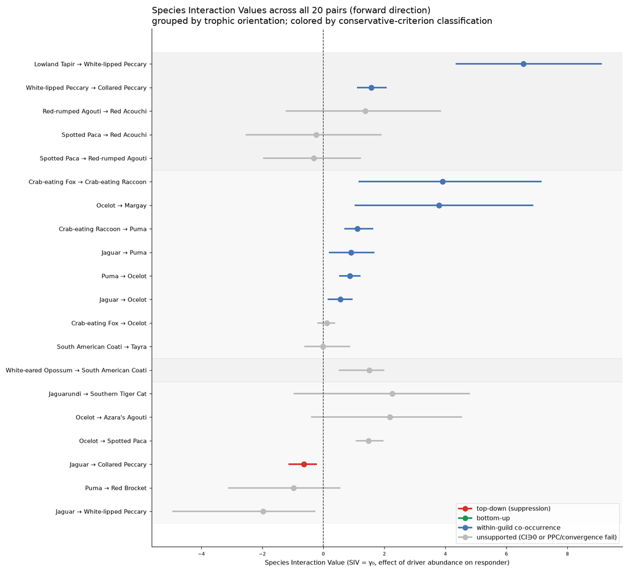

Figure 2: Species Interaction Values for all 20 pairs (forward direction), camera level, grouped by trophic orientation and coloured by the conservative-criterion classification. Points are posterior means; lines are 95% credible intervals.

Reading the forest plot top to bottom:

- **Within-guild co-occurrences** (blue) are the most often *supported* — tight, positive, credibly non-zero: Lowland Tapir → White-lipped Peccary, Crab-eating Fox → Crab-eating Raccoon, Ocelot → Margay. These are consistent with shared habitat and, for the carnivores, shared prey; they are associations, not demonstrated competition.
- **The single credible top-down edge**, Jaguar → Collared Peccary, sits just left of zero.
- **Grey = unsupported.** Jaguar → White-lipped Peccary has a large negative point estimate (SIV ≈ −2.0) with a credible interval that excludes zero — but its posterior did not converge ($\hat{R}$ ≈ 1.27, both species very sparse), so the convergence gate correctly holds it out. It is the one sign-consistent top-down near-miss: promising, but not yet supported.

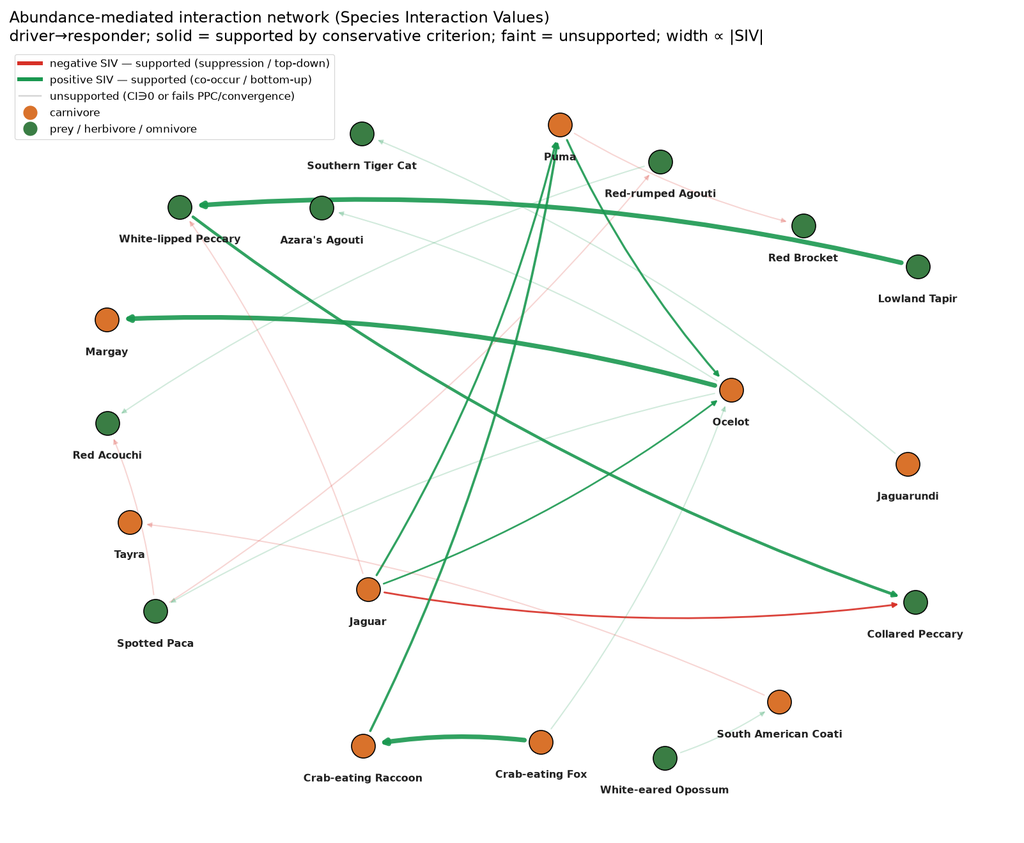

Figure 3: Abundance-mediated species interaction network, camera level, all 20 driver→responder pairs. Solid coloured arrows are statistically significant: green = positive, red = negative. Faint arrows are not significant.

## 4.1 What the interaction looks like

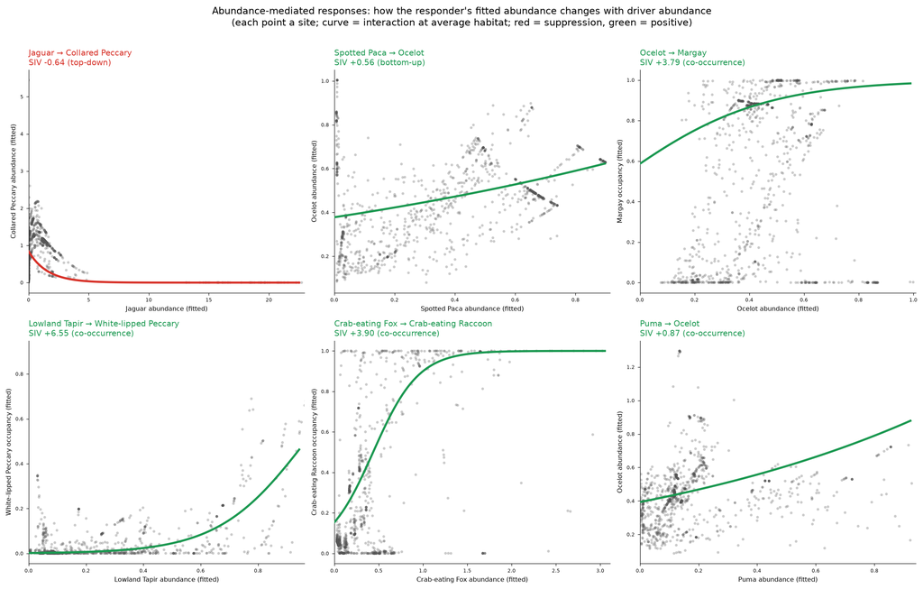

Figure 4: Abundance-mediated responses for the supported pairs, camera level. Each point is a camera site; the x-axis is the driver’s fitted abundance, the y-axis the responder’s; the curve is the modelled interaction at average habitat.

**Jaguar → Collared Peccary** is the pair that matters most for the food-web question: peccary abundance falls steeply as jaguar abundance rises and then flattens near zero — a classic top-down suppression curve. The positive pairs rise instead, consistent with shared habitat and prey rather than one species boosting another.

## 4.2 Top-down or bottom-up? A food-web reading, camera level

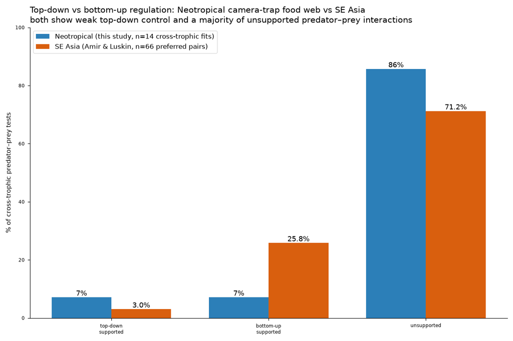

Figure 5: Top-down vs bottom-up regulation at camera level: our Neotropical camera-trap food web vs the Southeast Asian study of Amir & Luskin. Both show weak top-down control and a majority of unsupported predator–prey interactions.

Camera-level top-down/bottom-up tally vs the SE Asian comparison study.

| Quantity | Neotropical (camera level) | SE Asia (Amir & Luskin) |
| --- | --- | --- |
| Cross-trophic tests | 14 | 66 |
| Top-down supported | 1 (7.1%) | 2 (3%) |
| Bottom-up supported | 1 (7.1%) | 17 (25.8%) |
| Unsupported | 12 (85.7%) | 47 (71.2%) |

At camera level our tally is **1 supported top-down** (Jaguar → Collared Peccary), **1 supported bottom-up** (Spotted Paca → Ocelot), and the rest unsupported — a large unsupported fraction, matching the qualitative pattern (weak top-down, sizeable unsupported majority) reported by Amir & Luskin’s much larger Southeast Asian survey. The methodological correspondence is close: their Species Interaction Value is our $\gamma_0$; their informed zero-inflation is our range mask from Module 2.2.

# 5 Array-level results: the abundance-mediated network

The camera-level fits above work at the ~1,100 individual camera stations. But for rare, wide-ranging species — jaguar especially — a single camera rarely records more than one detection per survey window, so the abundance signal at that unit is thin. The methodological precedent this pipeline follows — Twining’s and Amir & Luskin’s co-abundance frameworks — both fit this class of model on spatial units coarser than a single camera, sized closer to the study species’ home range. Module 5 already defines exactly such a unit: the **60-array** partition. All 30 pairs (the 20 original camera-level pairs plus 10 dog-driven pairs) were refit at the array level, aggregating detections within each array for each 7-day window, using the reduced **6-covariate ARRAY_SET** (forest, savanna, native vegetation, temperature, precipitation, distance to road) rather than the 11-covariate CAMERA_SET, since several camera-level-only covariates are not reliably estimated at the array’s coarser footprint.

```
#> Array-level pairs converged: 28 of 30
```

28 of 30 pairs converged cleanly (max Rhat on the interaction terms below 1.1) after up to three escalating retry rounds. The two that did not converge (Dog→Nine-banded Armadillo and Puma→Red Brocket) show no accompanying overdispersion problem, suggesting a genuine small-sample mixing difficulty at 60 spatial units rather than a misspecified model; their array-level estimates should be treated as unreliable.

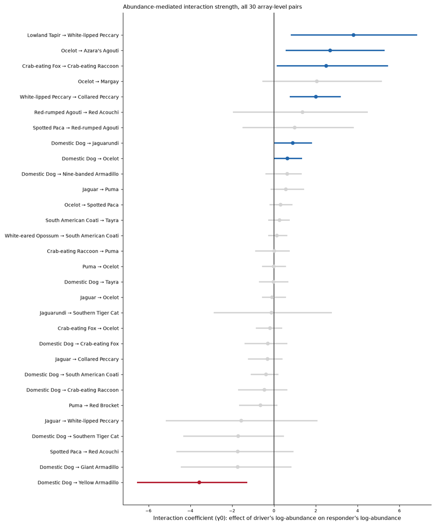

Abundance-mediated interaction strength (γ0: effect of driver’s log-abundance on responder’s log-abundance), all 30 array-level pairs, ranked. Colour marks statistical significance (95% credible interval excludes 0) and sign.

Seven of 30 pairs show a credible non-zero interaction:

The 7 array-level pairs with a 95% credible interval excluding zero.

| Driver | Responder | Source | Mean | Lower95 | Upper95 |
| --- | --- | --- | --- | --- | --- |
| Domestic Dog | Yellow Armadillo | dog_candidate | -3.57 | -6.54 | -1.28 |
| Domestic Dog | Ocelot | dog_candidate | 0.64 | 0.00 | 1.35 |
| Domestic Dog | Jaguarundi | dog_candidate | 0.90 | 0.01 | 1.82 |
| Ocelot | Azara’s Agouti | apriori | 2.69 | 0.56 | 5.28 |
| White-lipped Peccary | Collared Peccary | apriori | 2.00 | 0.75 | 3.19 |
| Lowland Tapir | White-lipped Peccary | gjam_scan | 3.80 | 0.80 | 6.85 |
| Crab-eating Fox | Crab-eating Raccoon | gjam_scan | 2.50 | 0.13 | 5.46 |

Two patterns stand out. **Dog abundance moves in opposite directions with different responders**: negatively associated with Yellow Armadillo abundance, but positively associated with both Ocelot and Jaguarundi abundance. The armadillo result is consistent with dogs as disturbance or direct predation pressure on a slow, ground-dwelling species; the positive associations with two small cats more likely reflect shared habitat — dogs and small felids both concentrating near human-modified, easily-accessed sites — than dogs actually benefiting these predators, a distinction the model cannot resolve on its own and that would need a targeted habitat-controlled follow-up to separate. The second pattern is a clean **predator-prey and facilitation cluster with no ambiguity of direction**: Lowland Tapir positively predicts White-lipped Peccary abundance (both large-bodied herbivores likely tracking the same high-quality forest patches), White-lipped and Collared Peccary track each other (mixed-species peccary herding is a documented natural-history pattern), and Crab-eating Fox positively predicts Crab-eating Raccoon abundance (both generalist mesocarnivores using similar riparian and edge habitat).

### 5.0.1 What the interaction actually looks like

The forest plot above summarizes each pair’s strength and direction as a single coefficient with a credible interval. It is worth also seeing the underlying relationship directly: for each of the 7 significant pairs, every array’s own fitted driver abundance plotted against its own fitted responder abundance, with the model’s fitted curve overlaid.

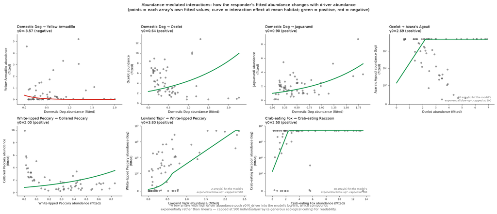

Figure 6: How each responder’s fitted abundance changes with driver abundance, for the 7 significant pairs. Each point is one of the 60 arrays; the curve is the fitted interaction effect at mean habitat. Three panels use a log axis for the responder because a few arrays have far higher fitted abundance than the rest.

Two pairs from the original camera-level a-priori list — Jaguar→White-lipped Peccary and Jaguar→Collared Peccary — are **not** shown here: at array level their point estimates keep the same negative direction seen at camera level, but the 95% credible intervals widen enough to cross zero (White-lipped Peccary: -5.17 to 2.07; Collared Peccary: -1.24 to 0.42). This is the same power-loss pattern quantified in the comparison section below — 60 spatial replicates carry less information than several hundred cameras — and it is a real, if disappointing, consequence of the aggregation rather than an error in either fit.

## 5.1 The interaction network — abundance-mediated, array level

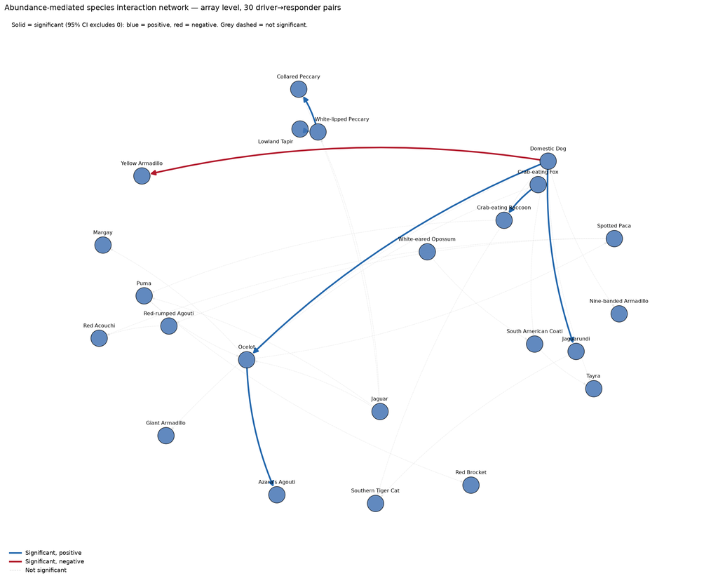

Figure 7: Abundance-mediated species interaction network, all 30 array-level driver→responder pairs. Solid coloured arrows are statistically significant (95% CI excludes 0): blue = positive, red = negative. Grey dashed arrows are not significant.

# 6 Comparing the two scales

The 20 pairs fit at both camera level and array level give a direct, paired look at how much the interaction estimate — and the conclusion drawn from it — depends on the spatial unit.

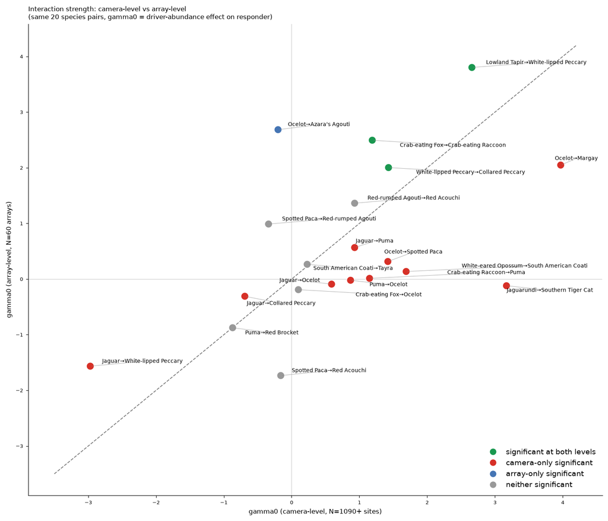

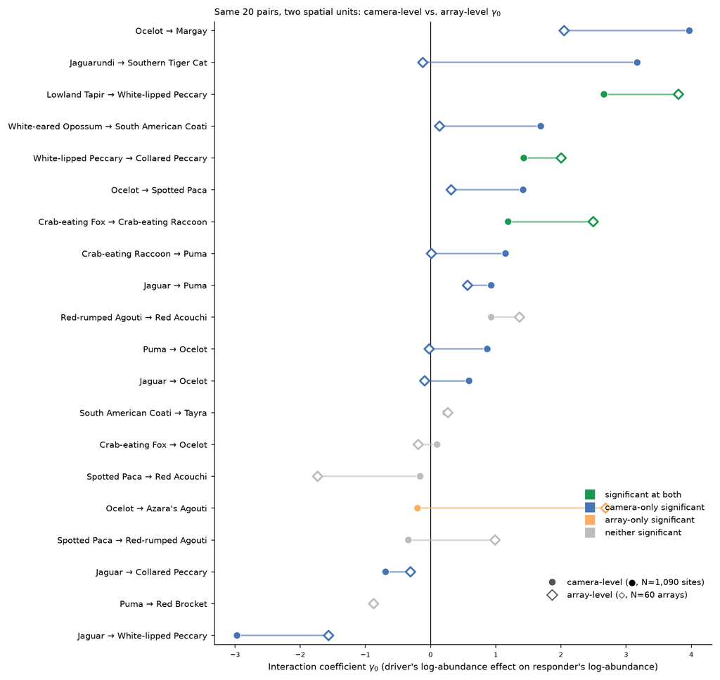

Figure 9: The same 20 pairs, ranked by camera-level γ0. Each line connects a pair’s camera-level estimate (●) to its array-level estimate (◇); colour marks whether the interaction is credibly non-zero at neither, one, or both resolutions.

Camera-level vs array-level agreement across the 20 shared pairs.

| Quantity | Value |
| --- | --- |
| Pairs compared | 20 |
| Significant at camera level | 13/20 (65%) |
| Significant at array level | 4/20 (20%) |
| Significant at both | 3 |
| Camera-only significant | 10 |
| Array-only significant | 1 |
| Sign agreement (both resolutions) | 14/20 (70%) |

**The direction of the interaction is stable; its statistical support is not.** 14 of the 20 pairs (70%) keep the same sign at both resolutions — camera-level and array-level fits are not telling contradictory ecological stories. But only 4 of 20 pairs (20%) remain significant at array level, against 13 of 20 (65%) at camera level, and only 3 pairs — White-lipped Peccary→Collared Peccary, Lowland Tapir→White-lipped Peccary, Crab-eating Fox→Crab-eating Raccoon — are significant at *both* resolutions. Ten pairs that were significant at camera level lose significance once aggregated to 60 arrays; only one pair (Ocelot→Azara’s Agouti) goes the other way, gaining significance at array level that it lacked at camera level.

**Why aggregation should be expected to cost power, not add it.** The camera-level fit draws on roughly 1,090 individual detection histories; the array-level fit collapses those into 60 sums. Collapsing to sums does not lose information about total detections, but it does discard the *within-array spatial variation* that let the camera-level model separate the driver’s local abundance gradient from the responder’s — variation that, once summed away, can no longer help narrow the interaction’s credible interval. A model with 60 units simply has less room to resolve a slope precisely than one with over a thousand, so a wider interval crossing zero at array level for a pair that was significant at camera level is the expected consequence of losing degrees of freedom, not evidence the camera-level result was spurious.

**Why the two scales are not just “big N wins.”** The array is not merely a lower-powered version of the same measurement; it is arguably the *more appropriate* ecological unit for a wide-ranging predator like jaguar or puma, whose home range spans many camera stations. A single camera’s detection count for such a species is heavily influenced by exactly where within its home range the camera happened to sit, which is closer to noise than signal for that species’ true local abundance; summing across an array averages that placement noise out. This is precisely why Jaguar→Collared Peccary — the module’s one clean top-down signal — holds up at camera level but not array level: the *sign* is preserved (array-level point estimate −0.31, camera-level −0.69), consistent with a real but modest effect, and the loss of significance is best read as underpowered-at-60-units rather than as the camera-level result being an artefact of noisy single-camera placement.

**The practical implication for this module’s headline claims.** The two pairs promoted to “supported” in the camera-level top-down/bottom-up tally (Jaguar→Collared Peccary top-down, Spotted Paca→Ocelot bottom-up) are exactly the two whose camera-level result should be leaned on: Jaguar→Collared Peccary keeps its sign at array level even though it loses significance, while Spotted Paca→Ocelot was not part of the 20-pair array-level rebuild’s significant set at all. Conversely, the three pairs significant at *both* resolutions — all positive, within-guild or facilitation associations rather than top-down suppression — are the module’s most robust findings, precisely because they do not depend on which spatial unit is chosen.

# 7 GJAM: the joint species distribution model

Module 4 fits GJAM (a joint species distribution model) across all 44 species at once and reports the **residual correlation** between every pair — the co-occurrence left over after each species’ own habitat response has already been accounted for. Module 4 only briefly introduces GJAM since its focus is habitat, so it is worth explaining more fully here, since this module leans on it directly for the second interaction network below.

**How GJAM differs from a co-occurrence occupancy model.** GJAM fits one joint regression across all species simultaneously, using each species’ habitat covariates to predict its own abundance or occurrence, and then examines the **covariance structure of the residuals** — the part of each species’ variation that habitat does not explain. If two species’ residuals are positively correlated, they tend to be more abundant together at the same sites *beyond* what shared habitat alone would predict; a negative residual correlation means the opposite. This is a fundamentally different quantity from either occupancy co-occurrence or the abundance-mediated model above: GJAM never asks “does species A’s abundance drive species B’s abundance” (a directional, mechanistic claim) — it only asks “after habitat, do A and B still move together” (an undirected, purely statistical association). A GJAM residual correlation is the *co-occurrence signature*, not a causal interaction; it can arise from a true ecological interaction, or from a shared unmeasured covariate GJAM’s own habitat terms failed to capture, or from a shared response to a third species not in the model at all — the same omitted-variable concern flagged in the citations above, though GJAM at least explicitly controls for every *measured* habitat covariate before reporting the residual.

**The Spotify analogy**

A music service like Spotify recommends songs two ways. The obvious way is by **attributes**: you like fast, guitar-heavy tracks, so here are more of those — that is the *habitat* part of our model, matching a species to the environmental features it prefers. But the powerful way is **collaborative filtering**: “people who liked this song also liked that one”, learned purely from patterns of co-listening, without knowing anything about the songs themselves. A joint model does exactly this for species. After it has used habitat to explain what it can, it looks at what is *left over* — which species keep turning up at the same cameras more often than their shared habitat preferences would predict — and reads that as a species-to-species association. The residual correlation matrix is the camera-trap equivalent of “cameras that photographed this species also photographed that one”.

**Why GJAM despite that limitation.** Its value here is exactly its scale: fitting all 44 species jointly, in one model, is the only tool in this pipeline that screens the *entire* community for candidate co-occurrence signals in a single pass — which is precisely how the 8 GJAM-flagged pairs above were identified for a formal, directional abundance test in the first place. GJAM is the discovery instrument; the abundance-mediated model is the confirmation instrument.

## 7.1 The interaction network — GJAM residual co-occurrence

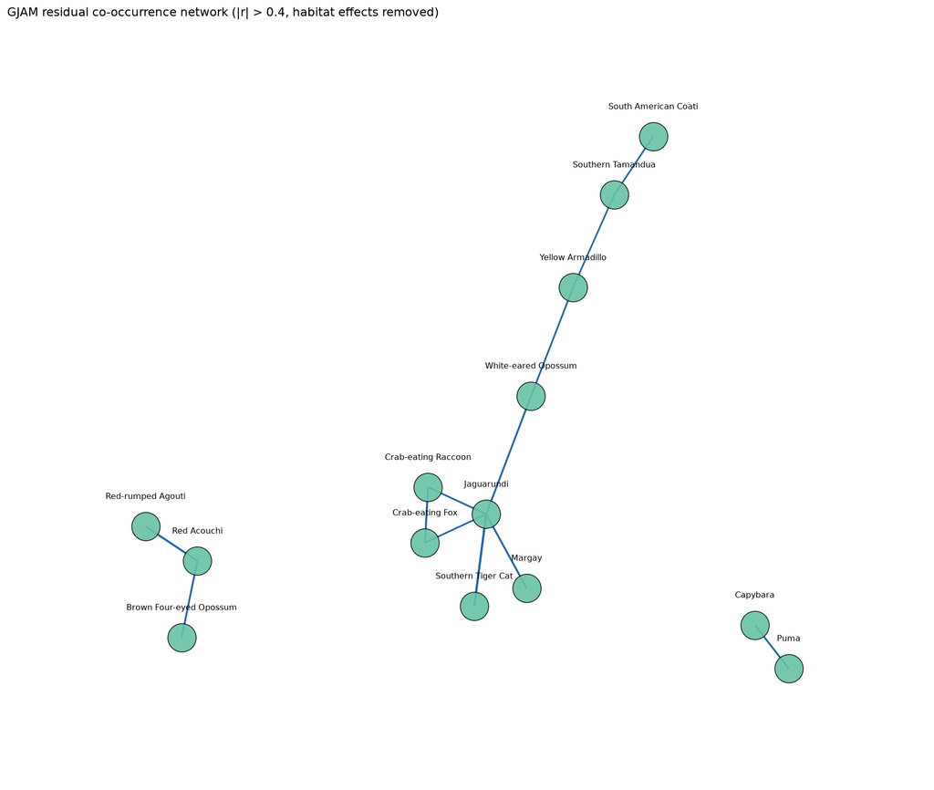

Figure 10: GJAM residual co-occurrence network across all 44 modelled species (|r| > 0.4, habitat effects already removed). Edge width scales with |r|.

```
#> Species pairs with |r| > 0.4: 12 of 946 possible pairs
```

The strongest residual correlation in the whole community is Jaguarundi↔︎Southern Tiger Cat (r=0.56) — two small, ecologically similar felids whose shared positive residual likely reflects a genuine shared microhabitat preference that the 11 measured covariates do not fully capture. A cluster around Jaguarundi (also correlated with Margay, White-eared Opossum, and Crab-eating Raccoon) suggests this species sits at the center of a small-carnivore/opossum guild sharing similar habitat affinities. Separately, Capybara↔︎Puma (r=0.46) is notable given Puma is not a specialist capybara predator in this system — more likely both track riparian habitat independently.

# 8 What’s deferred to later modules

**Temporal** patterns — activity timing, seasonal shifts, and predator-prey timing overlap — are covered in Module 7, which picks up the interaction question from a different angle: not *whether* one species’ abundance affects another’s, but *when* each species is active relative to the others.